# Lab10

jacksonhubbard

11/26/2018

```r
gss <- read_csv("https://raw.githubusercontent.com/matackett/sta210/master/data/gss2010.csv")
```

# Question 1.

Make the variable natmass a factor variable type. Then use the relevel() function to reformat natmass so that About Right is the baseline category (i.e. reference level).

```r
gss <- gss %>% mutate(natmass =as.factor(natmass))
gss <- gss %>% mutate(relevel(gss$natmass, ref = "About Right"))
```

# Question 2

```r
gss <- gss %>%
  mutate(polviews=factor(polviews,levels=c("Extremely Liberal","Liberal","Slightly Liberal",
                                           "Moderate","Slightly Conservative",
                                           "Conservative","Extremely Conservative")))
```

# a

Moderate political views occur most frequently in this dataset

```r
# counts for polviews
gss %>% group_by(polviews) %>% summarise(n = n())
```

```
## # A tibble: 7 x 2
##   polviews                   n
##   <fct>                  <int>
## 1 Extremely Liberal         67
## 2 Liberal                  239
## 3 Slightly Liberal         206
## 4 Moderate                 648
## 5 Slightly Conservative    226
## 6 Conservative             275
## 7 Extremely Conservative    70
```

# b

Yes there seems to be a relationship between a person’s political views and their views on mass transportation spending. It seems that the more conservative a person is, the more likely they are to respond that too much is being spent, while the more liberal a person is the more likely they are to respond that not enough money is spent on transportation.

# Question 3.

```r
# mean centered age and sei
gss <- gss %>% mutate(ageCent = age- mean(age), seiCent = sei - mean(sei))
```

# Question 4.

```r
model1 <- multinom(natmass ~ ageCent + sex + seiCent + region, data = gss)
kable(tidy(model1),format="markdown")
```

| y.level | term | estimate | std.error | statistic | p.value |
| --- | --- | --- | --- | --- | --- |
| Too Little | (Intercept) | 0.8718882 | 0.1297193 | -1.0568518 | 0.2905792 |
| Too Little | ageCent | 1.0062408 | 0.0030866 | 2.0156097 | 0.0438408 |
| Too Little | sexMale | 1.2427725 | 0.1043841 | 2.0821639 | 0.0373275 |
| Too Little | seiCent | 1.0153175 | 0.0027380 | 5.5520640 | 0.0000000 |
| Too Little | regionE. Sou. Central | 1.1056446 | 0.2461183 | 0.4080499 | 0.6832370 |
| Too Little | regionMiddle Atlantic | 0.9958382 | 0.1894251 | -0.0220168 | 0.9824346 |
| Too Little | regionMountain | 0.9733578 | 0.2238927 | -0.1206094 | 0.9040004 |
| Too Little | regionNew England | 0.9618560 | 0.2970328 | -0.1309300 | 0.8958307 |
| Too Little | regionPacific | 0.9273660 | 0.1805446 | -0.4176638 | 0.6761929 |
| Too Little | regionSouth Atlantic | 1.2976082 | 0.1644047 | 1.5846427 | 0.1130475 |
| Too Little | regionW. Nor. Central | 1.1041177 | 0.2475966 | 0.4000320 | 0.6891329 |
| Too Little | regionW. Sou. Central | 0.7583154 | 0.2049748 | -1.3497071 | 0.1771099 |
| Too Much | (Intercept) | 0.1916282 | 0.2101808 | -7.8608412 | 0.0000000 |
| Too Much | ageCent | 1.0108560 | 0.0049164 | 2.1961982 | 0.0280778 |
| Too Much | sexMale | 1.5227622 | 0.1678603 | 2.5052138 | 0.0122377 |
| Too Much | seiCent | 0.9934656 | 0.0047043 | -1.3935947 | 0.1634400 |
| Too Much | regionE. Sou. Central | 1.4471035 | 0.3569220 | 1.0354194 | 0.3004731 |
| Too Much | regionMiddle Atlantic | 0.7904044 | 0.3211202 | -0.7324689 | 0.4638824 |
| Too Much | regionMountain | 0.9121526 | 0.3620327 | -0.2539770 | 0.7995133 |
| Too Much | regionNew England | 1.5430696 | 0.4063130 | 1.0675851 | 0.2857077 |
| Too Much | regionPacific | 0.8950749 | 0.2909943 | -0.3809281 | 0.7032566 |
| Too Much | regionSouth Atlantic | 0.9155910 | 0.2720667 | -0.3241319 | 0.7458382 |
| Too Much | regionW. Nor. Central | 1.1794779 | 0.3807726 | 0.4335183 | 0.6646383 |
| Too Much | regionW. Sou. Central | 0.7613861 | 0.3279004 | -0.8313948 | 0.4057507 |

# Question 5.

# a

# b

# Question 6

# a

```r
# adding in polviews
model2 <- multinom(natmass ~ ageCent + sex +
                     seiCent + region + polviews, data=gss)
tidy(model2)
```

```
## # A tibble: 36 x 6
##    y.level    term                 estimate std.error statistic    p.value
##    <chr>      <chr>                   <dbl>     <dbl>     <dbl>      <dbl>
##  1 Too Little (Intercept)             2.08    0.310      2.36      1.84e-2
##  2 Too Little ageCent                 1.01    0.00315    2.44      1.47e-2
##  3 Too Little sexMale                 1.33    0.107      2.67      7.61e-3
##  4 Too Little seiCent                 1.01    0.00280    5.22      1.75e-7
##  5 Too Little regionE. Sou. Centr…    1.21    0.250      0.751     4.53e-1
##  6 Too Little regionMiddle Atlant…    0.969   0.193     -0.161     8.72e-1
##  7 Too Little regionMountain          1.01    0.228      0.0293    9.77e-1
##  8 Too Little regionNew England       0.898   0.300     -0.357     7.21e-1
##  9 Too Little regionPacific           0.854   0.184     -0.856     3.92e-1
## 10 Too Little regionSouth Atlantic    1.31    0.167      1.61      1.07e-1
## # ... with 26 more rows
```

# b

```r
# comparing model1 and model2
anova(model1,model2,test="Chisq")
```

```
## Likelihood ratio tests of Multinomial Models
##
## Response: natmass
##                                         Model Resid. df Resid. Dev   Test
## 1            ageCent + sex + seiCent + region      3438   3226.446
## 2 ageCent + sex + seiCent + region + polviews      3426   3158.370 1 vs 2
##      Df LR stat.      Pr(Chi)
## 1
## 2    12 68.07657 7.322021e-10
```

Looking at the output from this test, we see that the p value of 7.322021e-10 is less than the threshold of 0.05. Therefore, there is evidence that polvies is a significant predictor for the response variable of a person’s attitude towards government spending on public transportation.

# Question 7

```r
predprobs <- data.frame(pred = predict(model2,type="probs"))
```

# a

```r
# indicator variables for response
gss <- gss %>%
  mutate(aboutright = if_else(gss$natmass=="About Right",1,0),
         toomuch = if_else(gss$natmass=="Too Much",1,0),
         toolittle = if_else(gss$natmass=="Too Little",1,0))
```

# b

```r
# add residuals to gss
gss <- gss %>% mutate(
  aboutright.resid = aboutright - predprobs$pred.About.Right,
  toomuch.resid = toomuch - predprobs$pred.Too.Much,
  toolittle.resid = toolittle - predprobs$pred.Too.Little)
```

# Question 8

# a

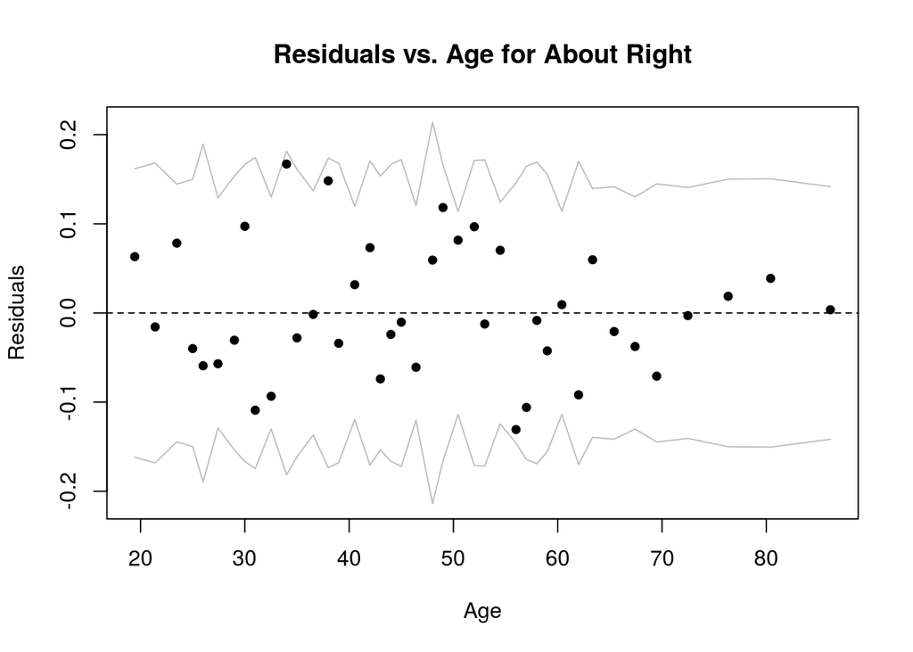

```r
# binned residual plots for response vs. age
binnedplot(gss$age, gss$aboutright.resid, xlab = "Age", ylab = "Residuals", main = "Residuals vs. Age for About Right")
```

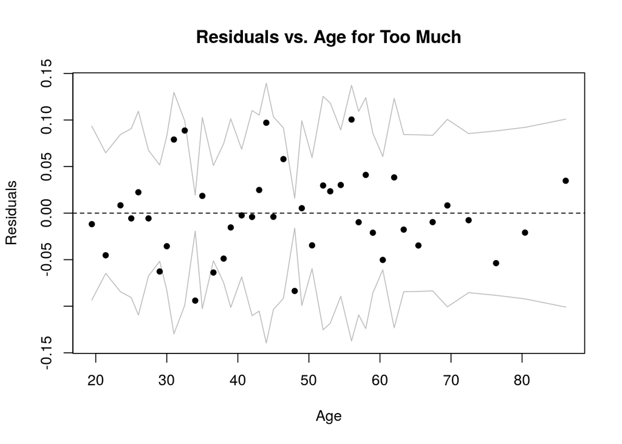

```r
binnedplot(gss$age, gss$toomuch.resid, xlab = "Age", ylab = "Residuals", main = "Residuals vs. Age for Too Much")
```

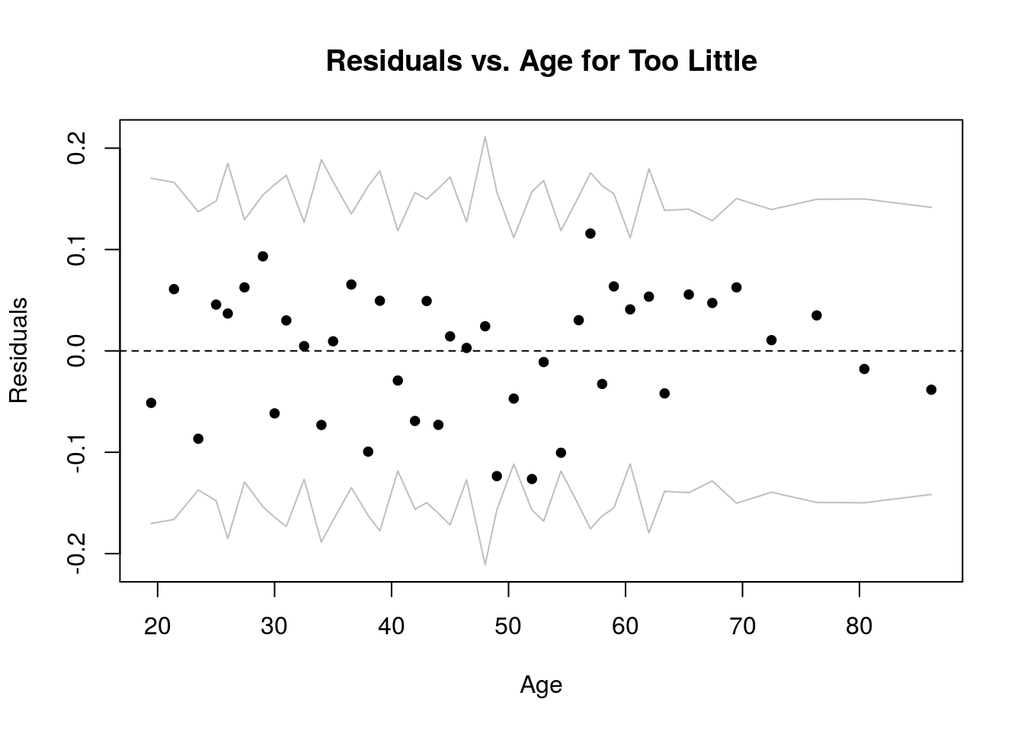

```r
binnedplot(gss$age, gss$toolittle.resid, xlab = "Age", ylab = "Residuals", main = "Residuals vs. Age for Too Little")
```

# b

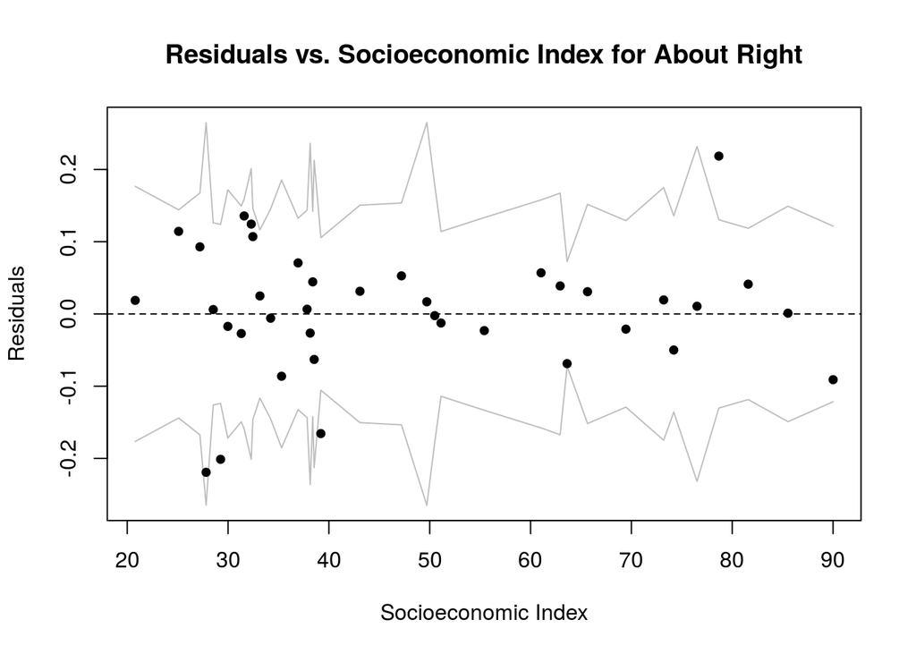

```r
# binned residual plots for response vs. sei
binnedplot(gss$sei, gss$aboutright.resid, xlab = "Socioeconomic Index", ylab = "Residuals", main = "Residuals vs. Socioeconomic Index for About Right")
```

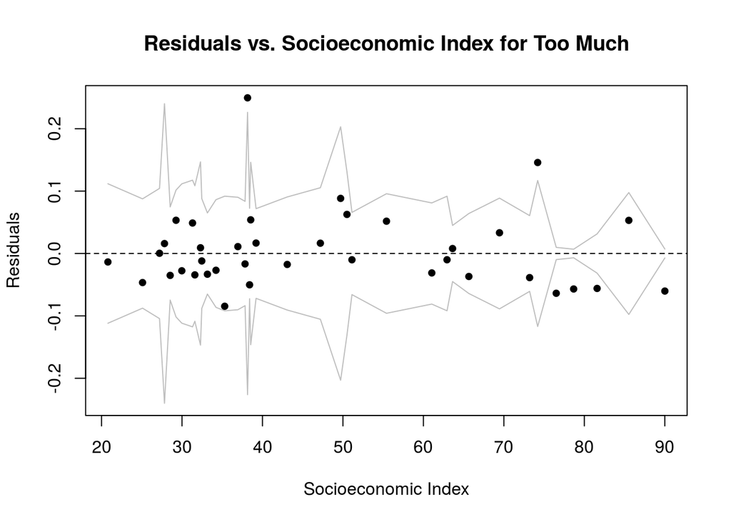

```r
binnedplot(gss$sei, gss$toomuch.resid, xlab = "Socioeconomic Index", ylab = "Residuals", main = "Residuals vs. Socioeconomic Index for Too Much")
```

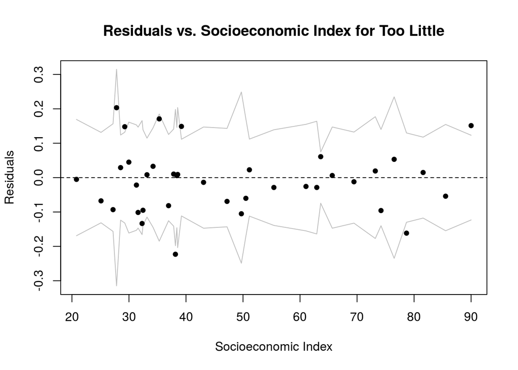

```r
binnedplot(gss$sei, gss$toolittle.resid, xlab = "Socioeconomic Index", ylab = "Residuals", main = "Residuals vs. Socioeconomic Index for Too Little")
```

# Question 9

```r
# average residuals for sex
gss %>% group_by(sex) %>%
  summarise(aboutright.avg = mean(aboutright.resid),
            toomuch.avg = mean(toomuch.resid),
            toolittle.avg=mean(toolittle.resid))
```

```
## # A tibble: 2 x 4
##   sex    aboutright.avg  toomuch.avg toolittle.avg
##   <chr>           <dbl>        <dbl>         <dbl>
## 1 Female  -0.000000300   0.000000264  0.0000000365
## 2 Male    -0.0000000618 -0.000000285  0.000000346
```

# b

```r
# average residuals for region
gss %>% group_by(region) %>%
  summarise(aboutright.avg = mean(aboutright.resid),
            toomuch.avg = mean(toomuch.resid),
            toolittle.avg=mean(toolittle.resid))
```

```
## # A tibble: 9 x 4
##   region          aboutright.avg  toomuch.avg toolittle.avg
##   <chr>                    <dbl>        <dbl>         <dbl>
## 1 E. Nor. Central  -0.00000652    0.00000236    0.00000415
## 2 E. Sou. Central   0.00000118    0.00000230   -0.00000348
## 3 Middle Atlantic  -0.0000000374 -0.00000197    0.00000201
## 4 Mountain          0.000000794   0.000000322  -0.00000112
## 5 New England       0.0000171    -0.00000868   -0.00000841
## 6 Pacific           0.00000113   -0.00000253    0.00000140
## 7 South Atlantic   -0.000000934   0.000000111   0.000000824
## 8 W. Nor. Central   0.00000382    0.00000237   -0.00000620
## 9 W. Sou. Central   0.000000111   0.00000219   -0.00000230
```

# c

```r
#average residuals for polviews
gss %>% group_by(polviews) %>%
  summarise(aboutright.avg = mean(aboutright.resid),
            toomuch.avg = mean(toomuch.resid),
            toolittle.avg=mean(toolittle.resid))
```

```
## # A tibble: 7 x 4
##   polviews               aboutright.avg  toomuch.avg toolittle.avg
##   <fct>                           <dbl>        <dbl>         <dbl>
## 1 Extremely Liberal      -0.00000107    -0.00000436    0.00000543
## 2 Liberal                 0.00000160    -0.000000650  -0.000000954
## 3 Slightly Liberal       -0.00000272     0.000000575   0.00000215
## 4 Moderate               -0.00000181     0.00000269   -0.000000872
## 5 Slightly Conservative   0.00000397    -0.00000492    0.000000950
## 6 Conservative           -0.00000000567  0.000000140  -0.000000134
## 7 Extremely Conservative  0.00000279    -0.00000444    0.00000165
```

# Question 10

# a

# b

The relationship between one’s political views and one’s attitude towards mass transportation spending is reflected below:

If a person is politically moderate the odds that they believe government spending on mass transportation is too little vs. about right is approximately e^(.3341) which is 1.3966.

If a person is politically slightly conservative the odds that they believe government spending on mass transportation is too little vs. about right is approximately e^(.4032) which is 1.4966.

If a person is politically conservative the odds that they believe government spending on mass transportation is too little vs. about right is approximately e^(.3115) which is 1.3654.

If a person is politically extremely conservative the odds that they believe government spending on mass transportation is too little vs. about right is approximately e^(.1183) which is 1.1255.

If a person is politically moderate the odds that they believe government spending on mass transportation is too much vs. about right is approximately e^(.3424) which is 1.4083.